# cdd-lab1

Thierry Barros

April 25, 2018

```r
episodes = read_csv(here("data/series_from_imdb.csv"),
                    progress = FALSE,
                    col_types = cols(.default = col_double(),
                                     series_name = col_character(),
                                     episode = col_character(),
                                     url = col_character(),
                                     season = col_character())) %>%
  filter(series_name %in% c("Supernatural", "New Girl", "Breaking Bad"))
```

# 1. Escolha um subconjunto de sÃ©ries (eu sugiro entre 2 e 4) para usar nesse problema.

As sÃ©ries escolhidas foram Supernatural, New Girl e Breaking bad.

# Responda as seguintes duas perguntas:

# Qual das séries que você escolheu é mais bem avaliada no IMDB? A diferença é grande? Pequena? Muda de acordo com as temporadas da série?

Primeiro fizemos a média geral das avaliações de cada série e colocamos em ordem decrescente. Como podemos ver a série mais bem avaliada foi Breaking Bad. Mas a diferença não é mutio grande entra ela e sobrenatural, mas entre Breaking bad e New Girl tem uma diferença considerável.

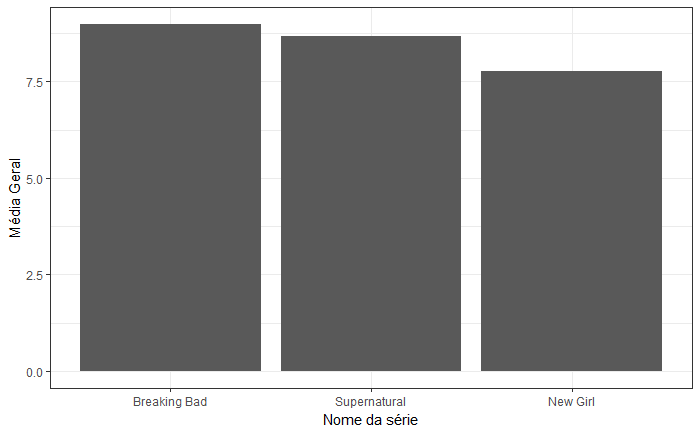

```r
avaliacao = group_by(episodes,series_name) %>% summarise(Total=mean(user_rating)) %>% arrange(Total)
ggplot(avaliacao, aes(x=reorder(series_name, -Total), y=Total)) + geom_bar(stat = "identity") +xlab("Nome da série") +
  ylab("Média Geral")
```

Para termos uma noção melhor da série mais bem avaliada a metodologia foi agrupar os dados por série e por temporada, depois fazer a média das notas de cada epsódio por temporada. Usamos o ggplot para ter uma vizualização dos resultados e o geom_bar para ilustrar a média. O eixo y representa a média de cada temporada e o eixo x as temporadas de cada série. OBS: Alguns valores não ter resultado, pois o número de temporadas por série é diferente.

Podemos ver que a média de avalição por temporada não muda muito em New Girl e Sobrenatural. Mas em Breaking bad ela foi aumentando indicando que a série foi melhorando a cada temporada.

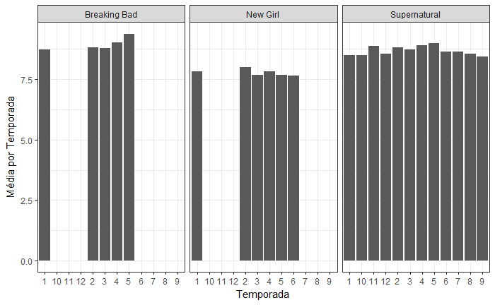

```r
media = group_by(episodes,series_name,season)%>%  summarise(Total=mean(user_rating))
media1 = group_by(media,series_name) %>% summarise(NotaGeral=mean(Total))
ggplot(media, aes(x=season, y=Total)) + geom_bar(stat = "identity")+
facet_wrap(~ series_name) + xlab("Temporada") + ylab("Média por Temporada")
```

# b. Qual das séries que você escolheu tem episódios de qualidade mais irregular segundo o IMDB? A diferença é grande? Pequena?

Para responder essa pergunta utilizamos o desvio padrÃ£o.

Primeiro fizemos o desvio padrão geral de cada série. Podemos ver que a maior variação de qualidade é na série Sobrenatural.

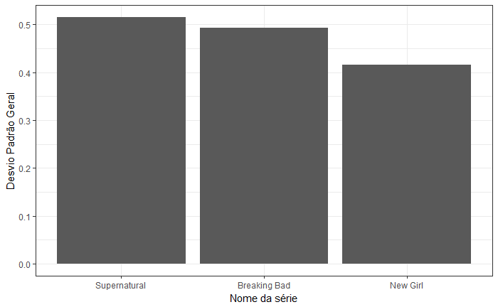

```r
desvio_padrao = group_by(episodes,series_name) %>% summarise(desvio=sd(user_rating))
ggplot(desvio_padrao , aes(x=reorder(series_name, -desvio), y=desvio)) + geom_bar(stat = "identity") +xlab("Nome da série") +
ylab("Desvio Padrão Geral")
```

Depois Separamos os dados por série para calcular o desvio padrão de cada um.

```r
supernatural = episodes %>% filter(series_name == "Supernatural")
newGirl = episodes %>% filter(series_name == "New Girl")
breakingBad = episodes %>% filter(series_name == "Breaking Bad")
s_desvio = group_by(supernatural,season) %>% summarise(desvio=sd(user_rating))
n_desvio = group_by(newGirl,season) %>% summarise(desvio=sd(user_rating))
b_desvio = group_by(breakingBad,season) %>% summarise(desvio=sd(user_rating))
```

Calculamos o desvio padrão de cada temporada de cada série para ver a variação de qualidade por temporada.

Sobrenatural:

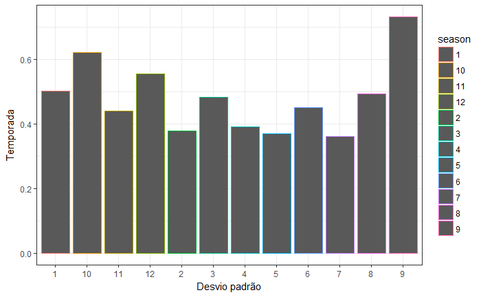

```r
s_desvio %>%
  ggplot(aes(x = season, y = desvio, color = season)) +
  geom_bar(stat = "identity") +xlab("Desvio padrão") +
  ylab("Temporada")
```

New girl:

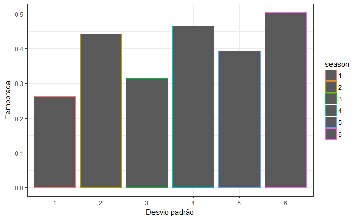

```r
n_desvio %>%
  ggplot(aes(x = season, y = desvio, color = season)) +
  geom_bar(stat = "identity")+xlab("Desvio padrão") +
  ylab("Temporada")
```

Breaking Bad:

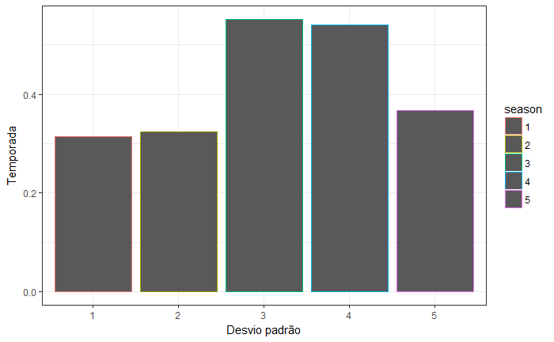

```r
b_desvio %>%
  ggplot(aes(x = season, y = desvio, color = season)) +
  geom_bar(stat = "identity") +xlab("Desvio padrão") +
  ylab("Temporada")
```

Para ter uma noção ainda melhor usamos as avaliação dadas por ep de cada temporada de cada série, para ver como é a variação de qualidade.

Podemos perceber que em breaking bad na 3° temporada do episódio 5 ao 10 tem uma queda brusca de qualidade.

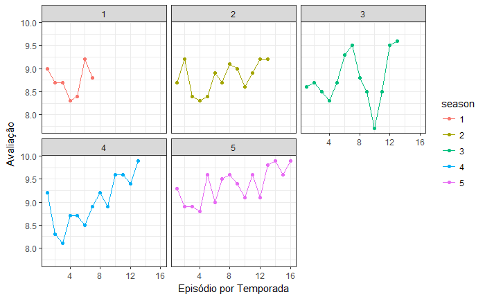

```r
breakingBad %>%
  ggplot(aes(x = season_ep, y = user_rating, color = season)) +
  geom_line() +
  geom_point() +
  facet_wrap(~ season)+ xlab("Episódio por Temporada") +
  ylab("Avaliação")
```

Em sobrenaturla a maior queda foi na temporada 9 episÃ³dio 20.

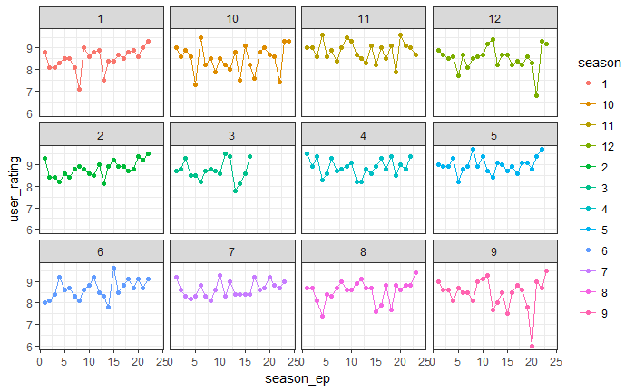

```r
supernatural %>%
  ggplot(aes(x = season_ep, y = user_rating, color = season)) +
  geom_line() +
  geom_point() +
  facet_wrap(~ season)
```

Em New Girl o contrário podemos ver que o último episódio da 6° temporada teve uma avaliação muito boa, comparado aos outros.

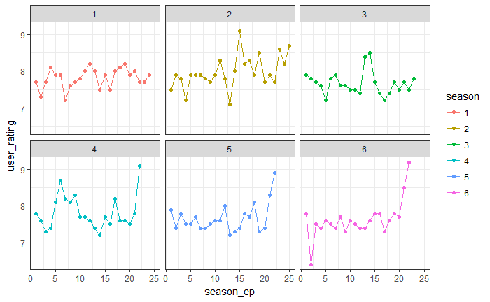

```r
newGirl %>%
  ggplot(aes(x = season_ep, y = user_rating, color = season)) +
  geom_line() +
  geom_point() +
  facet_wrap(~ season)
```

Agora outra forma de vizualizarmos foi utilização do boxplot para ver o IQR, por série e por temporada.

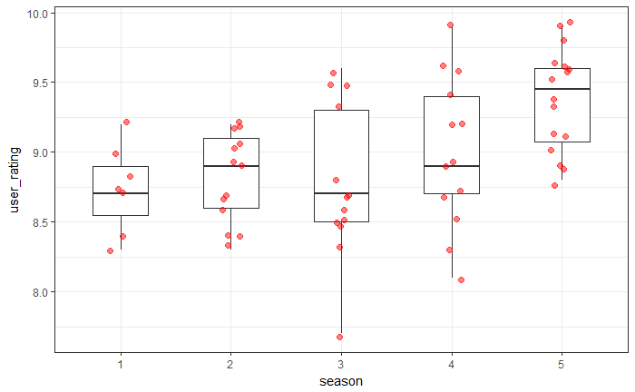

```r
breakingBad %>%
    ggplot(aes(x = season, y = user_rating)) +
    geom_boxplot(width = .5, outlier.color = NA) +
    geom_jitter(width = .1, size = 2, alpha = .5, color = "red")
```

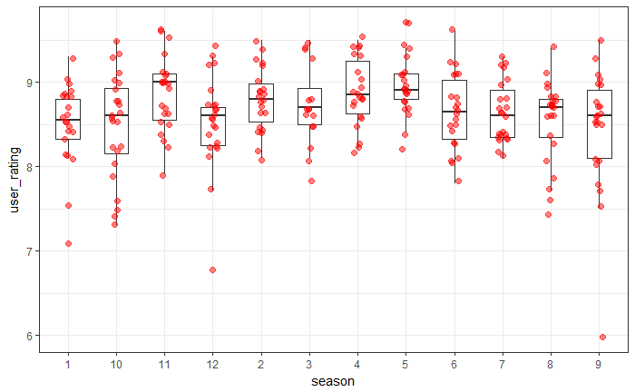

```r
supernatural %>%
    ggplot(aes(x = season, y = user_rating)) +
    geom_boxplot(width = .5, outlier.color = NA) +
    geom_jitter(width = .1, size = 2, alpha = .5, color = "red")
```

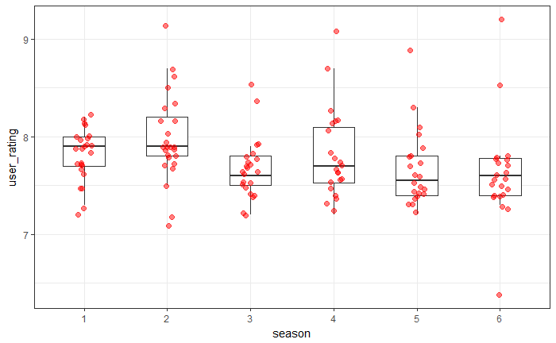

```r
newGirl %>%
    ggplot(aes(x = season, y = user_rating)) +
    geom_boxplot(width = .5, outlier.color = NA) +
    geom_jitter(width = .1, size = 2, alpha = .5, color = "red")
```